# Plotting coefficients

Andreas Olden

January 30, 2019

### One variable case

#### Sim 1: One variable, alfa(-1.8,-1.5), beta(-0.02), xmeans(0), xsd(12.3)

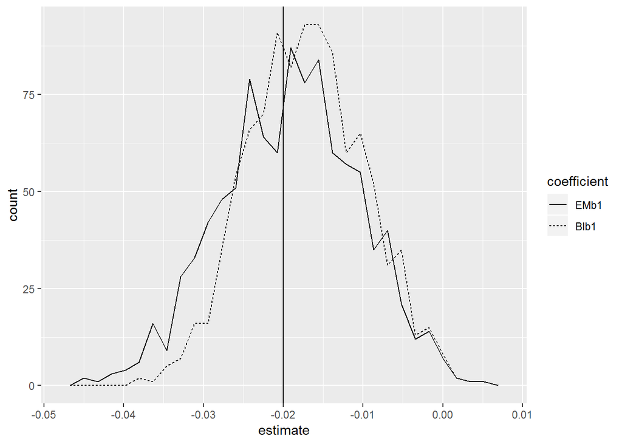

#### Sim 2: One variable, alfa(-3.0,-1.5), beta(-0.02), xmeans(0), xsd(12.3)

Increase alfa-deviation

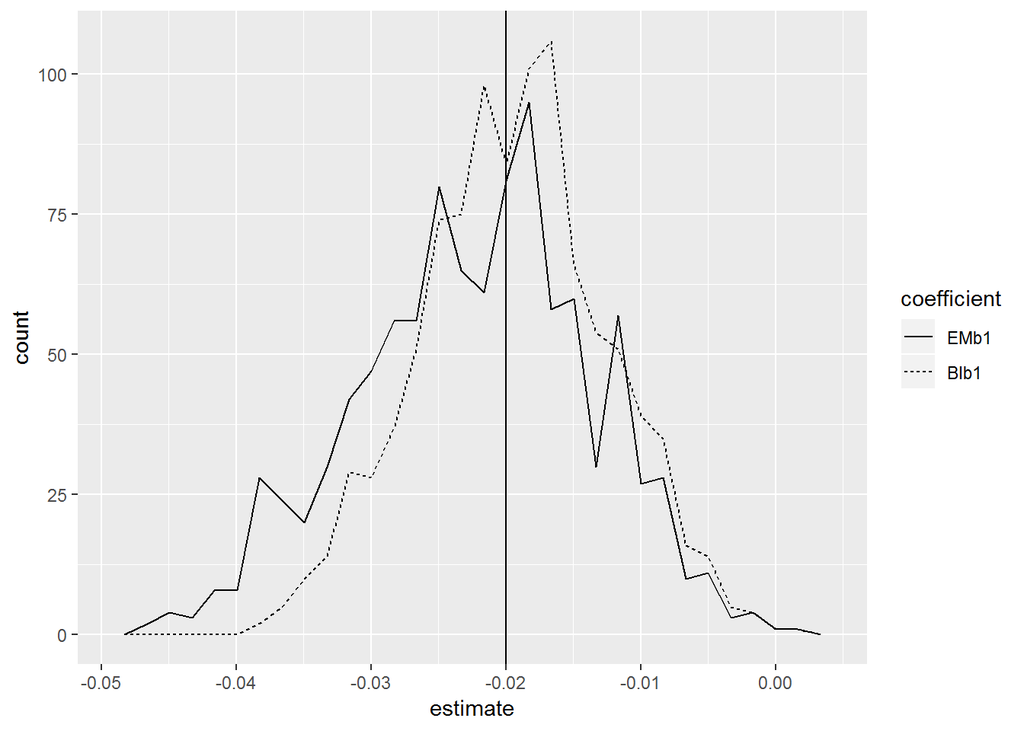

#### Sim 3: One variable, alfa(-1.8,-1.5), beta(-0.02), xmeans(0), xsd(123)

Ten times the standard deviation in x

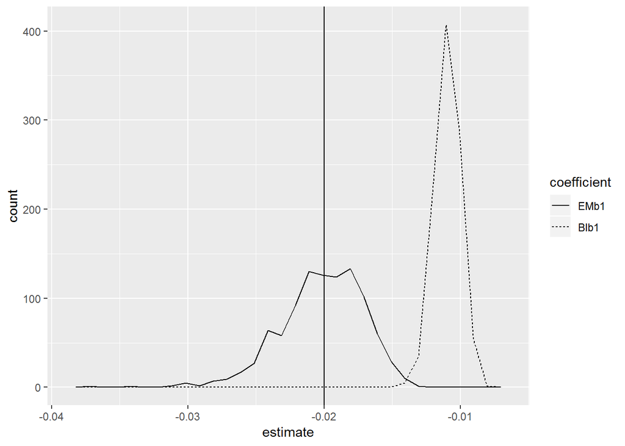

### Two variable case

#### Sim 4: alfa(-1.8,-1.5), beta(-0.02, 0.2), xmeans(0), xsd(12.3, 1.8), corr(0)

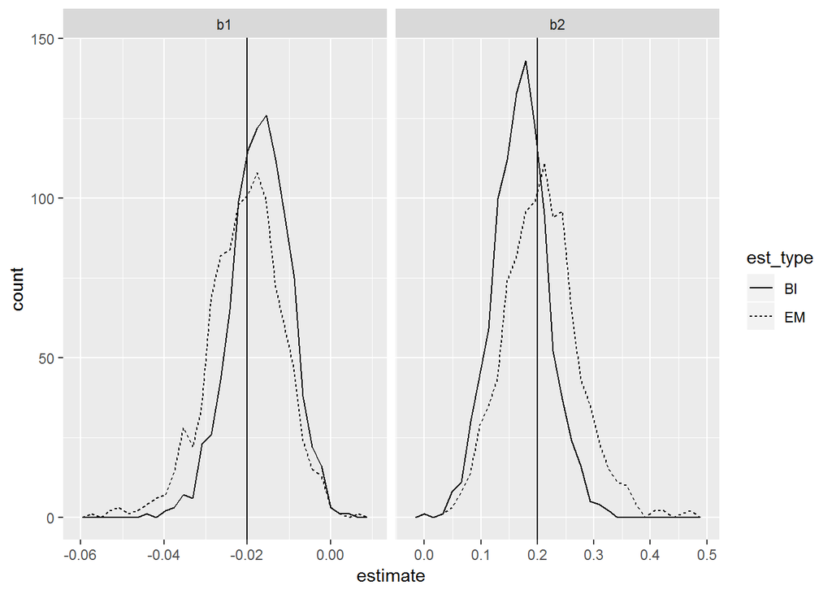

#### Sim 5: alfa(-1.8,-1.5), beta(-0.02, 0.2), xmeans(0), xsd(12.3, 1.8), corr(0.5)

Add correlation

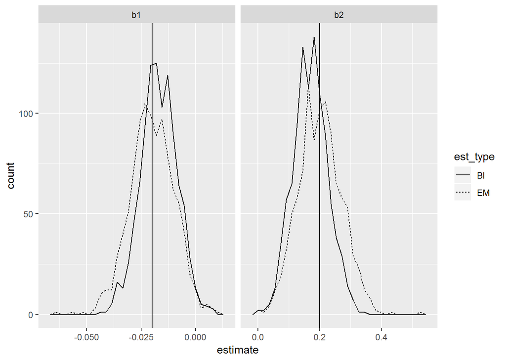

#### Sim 6: alfa(-1.8,-1.5), beta(-0.02, 0.2), xmeans(0), xsd(12.3, 1.8), corr(0.9)

Add even more correlation

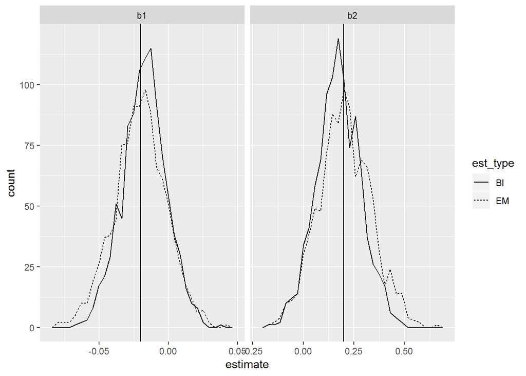

#### Sim 7: alfa(-1.8,-1.5), beta(-0.02, 0.2), xmeans(0), xsd(123, 1.8), corr(0.0)

Increase x1 standard deviations by 10

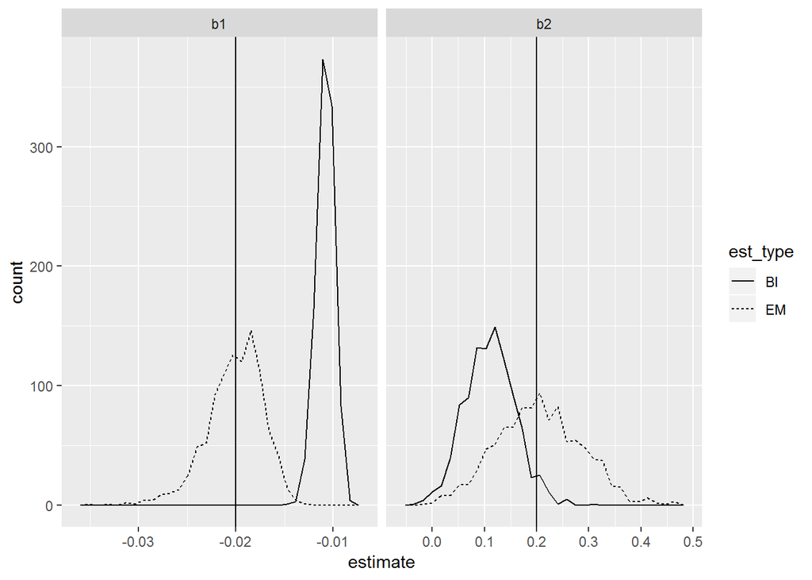

#### Sim 8: alfa(-1.8,-1.5), beta(-0.02, 0.2), xmeans(0), xsd(123, 18), corr(0.0)

Increase standard deviations by 10

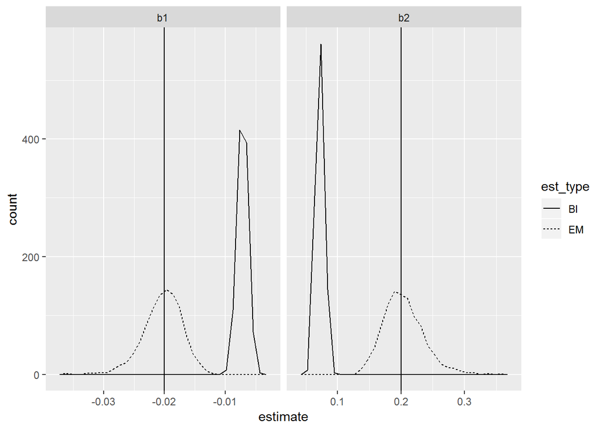

#### Sim 9: alfa(-1.8,-1.5), beta(-0.02, 0.2), xmeans(0), xsd(123, 18), corr(0.9)

Increase standard deviations by 10 and correlation to 0.9

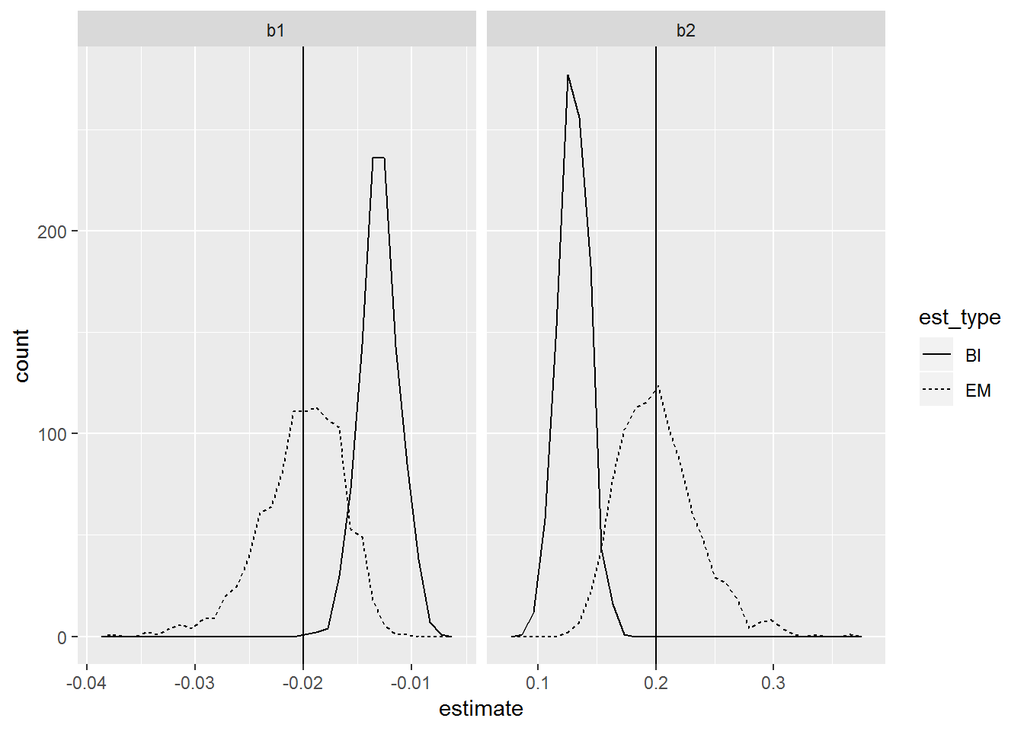

#### Sim 10: alfa(-1.8,-1.5), beta(0.023, -0.005, -0.200), xmeans(38.0, 14.2, 1.4), xsd(12.3, 9.1, 1.8), corr(1, 0.4 ,0.6, 0.4, 1, 0.5,0.6, 0.5, 1)

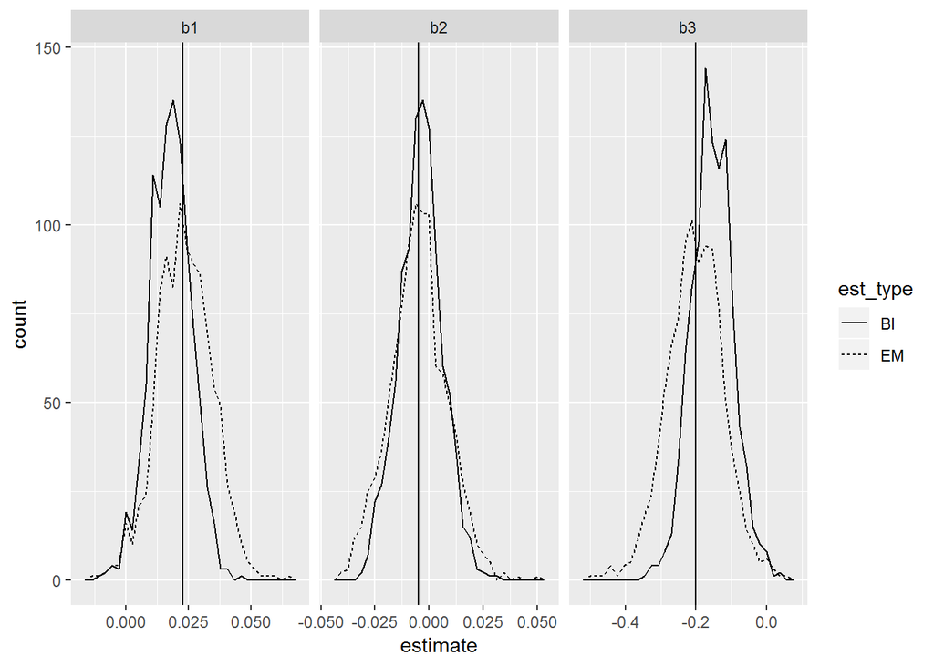